# Machine Learning in Practice: Course project

Ines Garmendia

8th August, 2016

# PART 0: Problem Setting

Our goal is to use data of 6 participants in a experiment to determine how well they did a bunch of barbell lifts.

In the experiments some exercises were correctly performed (class A), while others were deliberately incorrect (throwing elbows to the front: class B, lifting the dumbbell only halfway: class C,…). The *classe* variable records the type of exercise (one correct vs four incorrect), and our goal is to use data to predict this variable.

## Note for the reviewer

Most of ML models computed for this exercise take up to 30 minutes to compute. This file contains all the necessary code to reproduce the models, but it was compiled by loading a .RData file already containing the results. The .RData file can be found in the GitHub repo.

# PART 1: Reading and Pre-processing data

```r
# Set working directory
setwd("~/Documents/practical_ml_coursera")
load("~/Documents/practical_ml_coursera/project-results.RData") #local directory
pml.train <- read.csv2(file = "./data/pml-training.csv",
                       dec=".",
                       header = TRUE,
                       sep =",",
                       stringsAsFactors = TRUE)
#
pml.test <- read.csv2(file = "./data/pml-testing.csv",
                       dec=".",
                       header = TRUE,
                       sep =",",
                       stringsAsFactors = TRUE)
```

After reading the data we perform a quick check of the variables to see what kind of information they provide.

```r
summary(pml.train)
```

```
##        X            user_name    raw_timestamp_part_1 raw_timestamp_part_2
##  Min.   :    1   adelmo  :3892   Min.   :1.322e+09    Min.   :   294
##  1st Qu.: 4906   carlitos:3112   1st Qu.:1.323e+09    1st Qu.:252912
##  Median : 9812   charles :3536   Median :1.323e+09    Median :496380
##  Mean   : 9812   eurico  :3070   Mean   :1.323e+09    Mean   :500656
##  3rd Qu.:14717   jeremy  :3402   3rd Qu.:1.323e+09    3rd Qu.:751891
##  Max.   :19622   pedro   :2610   Max.   :1.323e+09    Max.   :998801
##
##           cvtd_timestamp  new_window    num_window      roll_belt
##  28/11/2011 14:14: 1498   no :19216   Min.   :  1.0   Min.   :-28.90
##  05/12/2011 11:24: 1497   yes:  406   1st Qu.:222.0   1st Qu.:  1.10
##  30/11/2011 17:11: 1440               Median :424.0   Median :113.00
##  05/12/2011 11:25: 1425               Mean   :430.6   Mean   : 64.41
##  02/12/2011 14:57: 1380               3rd Qu.:644.0   3rd Qu.:123.00
##  02/12/2011 13:34: 1375               Max.   :864.0   Max.   :162.00
##  (Other)         :11007
##    pitch_belt          yaw_belt       total_accel_belt kurtosis_roll_belt
##  Min.   :-55.8000   Min.   :-180.00   Min.   : 0.00             :19216
##  1st Qu.:  1.7600   1st Qu.: -88.30   1st Qu.: 3.00    #DIV/0!  :   10
##  Median :  5.2800   Median : -13.00   Median :17.00    -1.908453:    2
##  Mean   :  0.3053   Mean   : -11.21   Mean   :11.31    -0.016850:    1
##  3rd Qu.: 14.9000   3rd Qu.:  12.90   3rd Qu.:18.00    -0.021024:    1
##  Max.   : 60.3000   Max.   : 179.00   Max.   :29.00    -0.025513:    1
##                                                        (Other)  :  391
##  kurtosis_picth_belt kurtosis_yaw_belt skewness_roll_belt
##           :19216            :19216              :19216
##  #DIV/0!  :   32     #DIV/0!:  406     #DIV/0!  :    9
##  47.000000:    4                       0.000000 :    4
##  -0.150950:    3                       0.422463 :    2
##  -0.684748:    3                       -0.003095:    1
##  -1.750749:    3                       -0.010002:    1
##  (Other)  :  361                       (Other)  :  389
##  skewness_roll_belt.1 skewness_yaw_belt max_roll_belt     max_picth_belt
##           :19216             :19216     Min.   :-94.300   Min.   : 3.00
##  #DIV/0!  :   32      #DIV/0!:  406     1st Qu.:-88.000   1st Qu.: 5.00
##  0.000000 :    4                        Median : -5.100   Median :18.00
##  -2.156553:    3                        Mean   : -6.667   Mean   :12.92
##  -3.072669:    3                        3rd Qu.: 18.500   3rd Qu.:19.00
##  -6.324555:    3                        Max.   :180.000   Max.   :30.00
##  (Other)  :  361                        NA's   :19216     NA's   :19216
```

[output cut: 313 more lines]

```
##  Min.   :-446.00   Min.   :-1280.0   Min.   :-896.0   Min.   :-973.0
##  1st Qu.:-182.00   1st Qu.: -616.0   1st Qu.:   2.0   1st Qu.: 191.0
##  Median : -39.00   Median : -378.0   Median : 591.0   Median : 511.0
##  Mean   : -55.29   Mean   : -312.6   Mean   : 380.1   Mean   : 393.6
##  3rd Qu.:  26.00   3rd Qu.:  -73.0   3rd Qu.: 737.0   3rd Qu.: 653.0
##  Max.   : 291.00   Max.   :  672.0   Max.   :1480.0   Max.   :1090.0
##
##  classe
##  A:5580
##  B:3797
##  C:3422
##  D:3216
##  E:3607
##
##
```

Some variables have a high proportion of NA’s (see for instance *avg_yaw_forearm* with 19216 of NA’s, more than 97 percent); and others do not have relevant information, such as *X* variable. First, we manually remove non-relevant data (note: variable *user_name* should be relevant but we won’t be using it for this exercise). Secondly, we identify and remove variables with a high proportion of NA’s.

```r
n <- names(pml.train)
realvars <- n[-c(1:7)]
# Function
countNA <- function(var){
        sum(is.na(pml.train[, var])) / nrow(pml.train)
}
#n
s <- sapply(realvars, countNA)
s <- unname(s)
rmfurther <- realvars[which(s > 0.9)]
#summary(pml.train[, rmfurther]) #ok to remove them
#Remove
finalvars <- setdiff(realvars, rmfurther)
pml.train2 <- pml.train[,finalvars]
pml.test2  <- pml.test[, finalvars[-86]] # we don't have classe var in the test examples
```

Now that we have the relevant data we separate a training and a test set.

```r
set.seed(12345)
inTrain <- createDataPartition(y = pml.train$classe, p=0.75, list = FALSE)
training <- pml.train2[inTrain, ] #14718 rows
testing <- pml.train2[-inTrain, ] #4904 rows
```

We now focus on the training set; we will reserve the testing set to estimate generalization error.

```r
summary(training)
```

[output not shown]

We have variables with very little variability such as *skewness_roll_forearm*. We identify those (*near-zero variance* variables) using caret package.

```r
nzv <- nearZeroVar(training, saveMetrics = TRUE)
length(which(nzv$nzv == TRUE))
```

```
## [1] 33
```

We will remove 33 variables.

```r
keepvars <- names(training)[which(nzv$nzv == FALSE)]
training <- training[, keepvars] #53 variables and 14718 rows
testing <- testing[, keepvars] #53 variables and 4904 rows
testGen <- pml.test2[, keepvars[-53]]
```

## Principal Components Analysis

Variables are numeric and sometimes highly correlated, thus a dimensionality reduction should work.

```r
#Example: variabes related to X coordinate. Sometimes high correlations.
grep(pattern = "_x$", x = keepvars)
```

```
##  [1]  5  8 11 18 21 24 31 34 37 44 47 50
```

```r
cor(training[, grep(pattern = "_x$", x = keepvars)])
```

```
##                   gyros_belt_x accel_belt_x magnet_belt_x  gyros_arm_x
## gyros_belt_x        1.00000000   0.47604703    0.42641444  0.059917432
## accel_belt_x        0.47604703   1.00000000    0.89891400  0.060002025
## magnet_belt_x       0.42641444   0.89891400    1.00000000  0.062535913
## gyros_arm_x         0.05991743   0.06000202    0.06253591  1.000000000
## accel_arm_x        -0.37785982  -0.20511097   -0.16162062 -0.014281450
## magnet_arm_x        0.02367034   0.04418616    0.01303424 -0.028873633
## gyros_dumbbell_x   -0.06332738  -0.02080847   -0.01015891 -0.018666496
## accel_dumbbell_x   -0.13994436  -0.13778761   -0.19192183 -0.008937257
## magnet_dumbbell_x  -0.74378161  -0.47938519   -0.35137758 -0.062561096
## gyros_forearm_x     0.11620886   0.52448994    0.53971385  0.033811240
## accel_forearm_x    -0.21273032  -0.17757886   -0.17826805 -0.039374067
## magnet_forearm_x    0.04857475   0.04847968    0.02728449 -0.066659574
##                   accel_arm_x magnet_arm_x gyros_dumbbell_x
## gyros_belt_x      -0.37785982  0.023670343     -0.063327385
## accel_belt_x      -0.20511097  0.044186159     -0.020808474
## magnet_belt_x     -0.16162062  0.013034235     -0.010158908
## gyros_arm_x       -0.01428145 -0.028873633     -0.018666496
## accel_arm_x        1.00000000  0.811971226      0.035181940
## magnet_arm_x       0.81197123  1.000000000      0.005816505
## gyros_dumbbell_x   0.03518194  0.005816505      1.000000000
## accel_dumbbell_x   0.24647761  0.131538839      0.013683132
## magnet_dumbbell_x  0.49339784  0.040479277      0.055207053
## gyros_forearm_x   -0.05776951 -0.012807901      0.284691547
## accel_forearm_x   -0.14605986 -0.238782207      0.044882234
## magnet_forearm_x  -0.19039090 -0.156549413     -0.002519843
##                   accel_dumbbell_x magnet_dumbbell_x gyros_forearm_x
## gyros_belt_x          -0.139944362       -0.74378161      0.11620886
## accel_belt_x          -0.137787610       -0.47938519      0.52448994
## magnet_belt_x         -0.191921832       -0.35137758      0.53971385
## gyros_arm_x           -0.008937257       -0.06256110      0.03381124
## accel_arm_x            0.246477612        0.49339784     -0.05776951
## magnet_arm_x           0.131538839        0.04047928     -0.01280790
## gyros_dumbbell_x       0.013683132        0.05520705      0.28469155
## accel_dumbbell_x       1.000000000        0.43110481     -0.07034317
## magnet_dumbbell_x      0.431104810        1.00000000     -0.09824910
## gyros_forearm_x       -0.070343172       -0.09824910      1.00000000
## accel_forearm_x       -0.204326267        0.07520956     -0.12102501
## magnet_forearm_x      -0.037747778       -0.10523514     -0.02870390
##                   accel_forearm_x magnet_forearm_x
## gyros_belt_x          -0.21273032      0.048574754
## accel_belt_x          -0.17757886      0.048479684
## magnet_belt_x         -0.17826805      0.027284493
## gyros_arm_x           -0.03937407     -0.066659574
## accel_arm_x           -0.14605986     -0.190390899
## magnet_arm_x          -0.23878221     -0.156549413
## gyros_dumbbell_x       0.04488223     -0.002519843
## accel_dumbbell_x      -0.20432627     -0.037747778
## magnet_dumbbell_x      0.07520956     -0.105235142
## gyros_forearm_x       -0.12102501     -0.028703900
## accel_forearm_x        1.00000000      0.677164551
## magnet_forearm_x       0.67716455      1.000000000
```

```r
# Perform PCA processing with caret
# First identify numeric features
numericfeat <- names(training)[-which(names(training) == "classe")]
#
pca <- prcomp(x = training[, numericfeat], scale = TRUE)
summary(pca) # 10 components retain 76 percent of variance; 18 components retain 90 percent
```

```
## Importance of components:
##                           PC1    PC2    PC3     PC4     PC5     PC6
## Standard deviation     2.8887 2.8539 2.1657 2.07085 1.91786 1.73602
## Proportion of Variance 0.1605 0.1566 0.0902 0.08247 0.07073 0.05796
## Cumulative Proportion  0.1605 0.3171 0.4073 0.48978 0.56051 0.61847
##                            PC7     PC8     PC9    PC10   PC11    PC12
## Standard deviation     1.49395 1.44154 1.30656 1.22218 1.1738 1.05885
## Proportion of Variance 0.04292 0.03996 0.03283 0.02873 0.0265 0.02156
## Cumulative Proportion  0.66139 0.70135 0.73418 0.76291 0.7894 0.81096
##                           PC13    PC14    PC15    PC16    PC17    PC18
## Standard deviation     0.99013 0.93308 0.90480 0.88651 0.82720 0.75527
## Proportion of Variance 0.01885 0.01674 0.01574 0.01511 0.01316 0.01097
## Cumulative Proportion  0.82982 0.84656 0.86230 0.87742 0.89058 0.90155
##                          PC19    PC20   PC21    PC22    PC23    PC24
## Standard deviation     0.7248 0.69133 0.6408 0.62785 0.61312 0.58034
## Proportion of Variance 0.0101 0.00919 0.0079 0.00758 0.00723 0.00648
## Cumulative Proportion  0.9116 0.92084 0.9287 0.93632 0.94355 0.95002
##                           PC25    PC26    PC27    PC28    PC29   PC30
## Standard deviation     0.54996 0.53620 0.50079 0.48111 0.44494 0.4080
## Proportion of Variance 0.00582 0.00553 0.00482 0.00445 0.00381 0.0032
## Cumulative Proportion  0.95584 0.96137 0.96619 0.97064 0.97445 0.9777
##                           PC31    PC32    PC33    PC34    PC35    PC36
## Standard deviation     0.38991 0.35966 0.34774 0.33616 0.30361 0.28301
## Proportion of Variance 0.00292 0.00249 0.00233 0.00217 0.00177 0.00154
## Cumulative Proportion  0.98057 0.98306 0.98539 0.98756 0.98933 0.99087
##                           PC37    PC38    PC39    PC40    PC41    PC42
## Standard deviation     0.25273 0.23771 0.23430 0.19882 0.19303 0.18315
## Proportion of Variance 0.00123 0.00109 0.00106 0.00076 0.00072 0.00065
## Cumulative Proportion  0.99210 0.99319 0.99424 0.99500 0.99572 0.99637
##                           PC43    PC44    PC45    PC46    PC47    PC48
## Standard deviation     0.17948 0.17062 0.16919 0.16282 0.14751 0.14149
## Proportion of Variance 0.00062 0.00056 0.00055 0.00051 0.00042 0.00039
## Cumulative Proportion  0.99699 0.99755 0.99810 0.99861 0.99902 0.99941
##                           PC49    PC50    PC51    PC52
## Standard deviation     0.11346 0.09926 0.07638 0.04636
## Proportion of Variance 0.00025 0.00019 0.00011 0.00004
## Cumulative Proportion  0.99966 0.99985 0.99996 1.00000
```

We will choose either 10 or 18 principal components, in order to evaluate if 18 vs 10 components is worth enough for performance.

```r
# Choose scale = true to normalize features
preProc1 <- preProcess(training[, numericfeat], method = "pca", scale = TRUE, center = TRUE, pcaComp = 10)
preProc2 <- preProcess(training[, numericfeat], method = "pca", scale = TRUE, center = TRUE, pcaComp = 18)
#
train1 <- predict.preProcess(preProc1, training)
test1 <- predict.preProcess(preProc1, testing)
#
train2 <- predict.preProcess(preProc2, training)
test2 <- predict.preProcess(preProc2, testing)
# we will also apply this preprocessing to the test set. Reserve for the final assessment.
testGen <- predict.preProcess(preProc2, testGen )
```

# PART 2: Training models - Experiment

We choose the Random Forest paradigm which works well in much of settings. But, to be sure that this type of models works, we will do the following experiment. We separate the training set in 10 folds of equal size. Then we train a model for the first fold, for the first and second,…etc, both for 10 and for 18 principal components, and we will monitor how much accuracy is gained each time.

## Separating folds for the Random Forest experiment

We compute 10 independent, random folds:

```r
set.seed(12345)
folds <- createFolds(train1$classe, k = 10, list = TRUE, returnTrain = FALSE)
folds_2 <- createFolds(train2$classe, k = 10, list = TRUE, returnTrain = FALSE)
#returns a list of folds, we have to extract each sample in a cumulative way
fold1 <- train1[folds[[1]], ]; fold1_2 <- train2[folds_2[[1]], ]
fold2 <- train1[c(folds[[1]], folds[[2]]), ]; fold2_2 <- train2[c(folds_2[[1]], folds_2[[2]]), ]
fold3 <- train1[c(folds[[1]], folds[[2]], folds[[3]]), ]; fold3_2 <- train2[c(folds_2[[1]], folds_2[[2]], folds_2[[3]]), ]
fold4 <- train1[c(folds[[1]], folds[[2]], folds[[3]], folds[[4]]), ]; fold4_2 <- train2[c(folds_2[[1]], folds_2[[2]], folds_2[[3]], folds_2[[4]]), ]
fold5 <- train1[c(folds[[1]], folds[[2]], folds[[3]], folds[[4]], folds[[5]]), ]; fold5_2 <- train2[c(folds_2[[1]], folds_2[[2]], folds_2[[3]], folds_2[[4]], folds_2[[5]]), ]
fold6 <- train1[c(folds[[1]], folds[[2]], folds[[3]], folds[[4]], folds[[5]], folds[[6]]), ]; fold6_2 <- train2[c(folds_2[[1]], folds_2[[2]], folds_2[[3]], folds_2[[4]], folds_2[[5]], folds_2[[6]]), ]
fold7 <- train1[c(folds[[1]], folds[[2]], folds[[3]], folds[[4]], folds[[5]], folds[[6]], folds[[7]]), ]; fold7_2 <- train2[c(folds_2[[1]], folds_2[[2]], folds_2[[3]], folds_2[[4]], folds_2[[5]], folds_2[[6]], folds_2[[7]]), ]
fold8 <- train1[c(folds[[1]], folds[[2]], folds[[3]], folds[[4]], folds[[5]], folds[[6]], folds[[7]], folds[[8]]), ]; fold8_2 <- train2[c(folds_2[[1]], folds_2[[2]], folds_2[[3]], folds_2[[4]], folds_2[[5]], folds_2[[6]], folds_2[[7]],folds_2[[8]]), ]
fold9 <- train1[c(folds[[1]], folds[[2]], folds[[3]], folds[[4]], folds[[5]], folds[[6]], folds[[7]], folds[[8]], folds[[9]]), ]; fold9_2 <- train2[c(folds_2[[1]], folds_2[[2]], folds_2[[3]], folds_2[[4]], folds_2[[5]], folds_2[[6]], folds_2[[7]], folds_2[[8]], folds_2[[9]]), ]
```

## Function for accuracy assessment

We will use our own function to assess accuracy.

```r
accur <- function(fit, validation){
        pred <- predict(object = fit, validation)
        sum(diag(table(validation$classe, pred))) / length(pred)
}
```

## Fitting Random Forests to the folds

```r
sizes1 <- c(nrow(fold1),
            nrow(fold2),
            nrow(fold3),
            nrow(fold4),
            nrow(fold5),
            nrow(fold6),
            nrow(fold7),
            nrow(fold8),
            nrow(fold9))
sizes2 <- c(nrow(fold1_2),
            nrow(fold1_2),
            nrow(fold3_2),
            nrow(fold4_2),
            nrow(fold5_2),
            nrow(fold6_2),
            nrow(fold7_2),
            nrow(fold8_2),
            nrow(fold9_2))
df <- data.frame(sizes1, sizes2)
df$accur1 <- rep(0, 9) #accuracies with 10 PC
df$accur2 <- rep(0, 9) #accuracies with 18 PC
#
validation = train1[folds[[10]], ]
validation_2 = train2[folds[[10]], ]
fit1 <- train(classe ~ ., data = fold1, method = "rf", prox = FALSE)
df[1,]$accur1 <- accur(fit1, validation = validation)
fit1_2 <- train(classe ~ ., data = fold1_2, method = "rf", prox = FALSE)
df[1,]$accur2 <- accur(fit1_2, validation = validation_2)
#
fit2 <- train(classe ~ ., data = fold2, method = "rf", prox = FALSE)
df[2,]$accur1 <- accur(fit2, validation = validation)
fit2_2 <- train(classe ~ ., data = fold2_2, method = "rf", prox = FALSE)
df[2,]$accur2 <- accur(fit2_2, validation = validation_2)
#
fit3 <- train(classe ~ ., data = fold3, method = "rf", prox = FALSE)
df[3,]$accur1 <- accur(fit3, validation = validation)
fit3_2 <- train(classe ~ ., data = fold3_2, method = "rf", prox = FALSE)
df[3,]$accur2 <- accur(fit3_2, validation = validation_2)
#
fit4 <- train(classe ~ ., data = fold4, method = "rf", prox = FALSE)
df[4,]$accur1 <- accur(fit4, validation = validation)
fit4_2 <- train(classe ~ ., data = fold4_2, method = "rf", prox = FALSE)
df[4,]$accur2 <- accur(fit4_2, validation = validation_2)
#
fit5 <- train(classe ~ ., data = fold5, method = "rf", prox = FALSE)
df[5,]$accur1 <- accur(fit5, validation = validation)
fit5_2 <- train(classe ~ ., data = fold5_2, method = "rf", prox = FALSE)
df[5,]$accur2 <- accur(fit5_2, validation = validation_2)
#
fit6 <- train(classe ~ ., data = fold6, method = "rf", prox = FALSE)
df[6,]$accur1 <- accur(fit6, validation = validation)
fit6_2 <- train(classe ~ ., data = fold6_2, method = "rf", prox = FALSE)
df[6,]$accur2 <- accur(fit6_2, validation = validation_2)
#
fit7 <- train(classe ~ ., data = fold7, method = "rf", prox = FALSE)
df[7,]$accur1 <- accur(fit7, validation = validation)
fit7_2 <- train(classe ~ ., data = fold7_2, method = "rf", prox = FALSE)
df[7,]$accur2 <- accur(fit7_2, validation = validation_2)
#
fit8 <- train(classe ~ ., data = fold8, method = "rf", prox = FALSE)
df[8,]$accur1 <- accur(fit8, validation = validation)
fit8_2 <- train(classe ~ ., data = fold8_2, method = "rf", prox = FALSE)
df[8,]$accur2 <- accur(fit8_2, validation = validation_2)
#
fit9 <- train(classe ~ ., data = fold9, method = "rf", prox = FALSE)
df[9,]$accur1 <- accur(fit9, validation = validation)
fit9_2 <- train(classe ~ ., data = fold9_2, method = "rf", prox = FALSE)
df[9,]$accur2 <- accur(fit9_2, validation = validation_2)
```

## Plotting the results

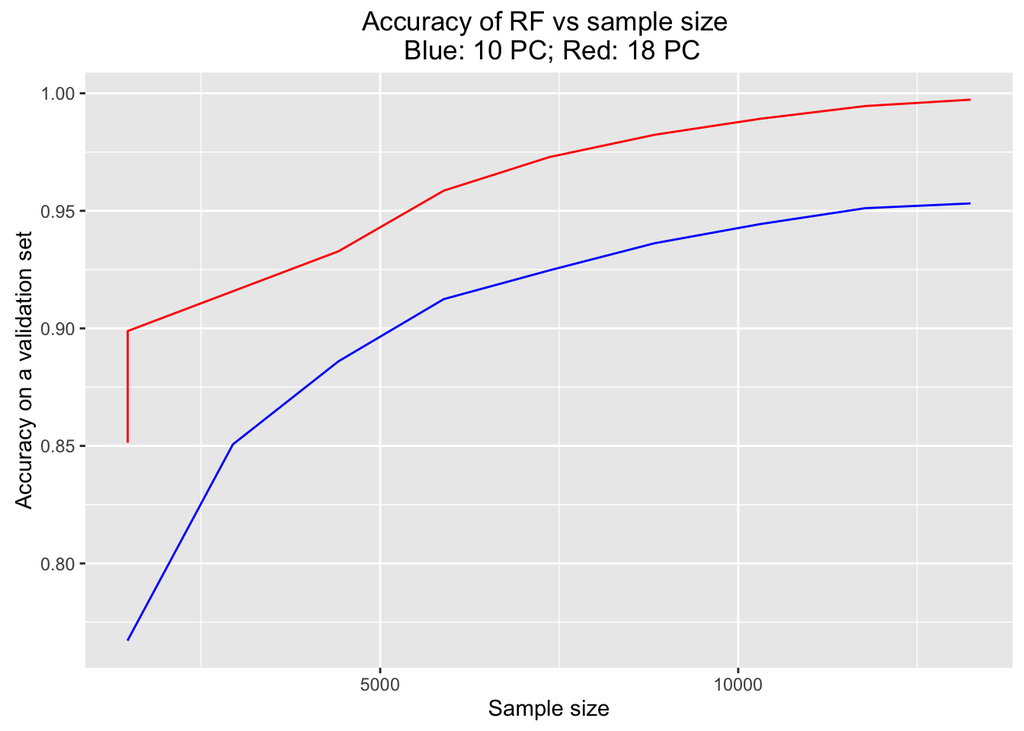

```r
ggplot(data = df, aes(x=sizes1, y =accur1)) + geom_line(col = 'blue') +
        geom_line(aes(x = sizes2, y = accur2), col = 'red') +
        ggtitle("Accuracy of RF vs sample size \n Blue: 10 PC; Red: 18 PC") +
        xlab("Sample size") + ylab("Accuracy on a validation set")
```

# PART 3: Final model

We have shown that with a random forest model, we gain higher accuracy each time we increment sample size, so we have found a model that really learns from data. Also, accuracy is visibly better with 18 principal components - although computing time is obviusly higher than with 10.

We will now use all the available training data (dataset *train2*) to estimate a final RF model using 18 principal components. This computation takes more than 1h to perform.

```r
# fit.final1 <- train(classe ~ ., data = train1, method = "rf", prox = FALSE)
# accur(fit.final1, validation = test1) #[1] 0.954323
fit.final2 <- train(classe ~ ., data = train2, method = "rf", prox = FALSE)
```

The accuracy on the test set is 97.7. The confussion matrix is shown below.

```r
accur(fit.final2, validation = test2) #[1] 0.9773654
```

```
## [1] 0.9773654
```

```r
predictions <- predict(object = fit.final2, test2)
#save.image("~/Google Drive/Coursera/course project/course-final.RData")
# Confussion matrix
table(test2$classe, predictions)
```

```
##    predictions
##        A    B    C    D    E
##   A 1383    6    5    1    0
##   B   19  916   13    0    1
##   C    3    8  836    4    4
##   D    0    3   24  776    1
##   E    0    4    7    8  882
```

# APPENDIX: Predict quizz cases

```r
quizz.pred <- predict(object = fit.final2, newdata = testGen)
length(quizz.pred) #20 predictions!!
quizz.pred
```

[output not shown]